# Beta Binomial Regression - 3pt %

Patrick Ward

4/24/2022

## Plotting

- Number of 3 pt attempts has an influence on a players 3pt%
- As 3 pt attempts increase so does 3pt% – Better 3 pt shooters take more 3 pt shots and their teams put them in position to take those shots

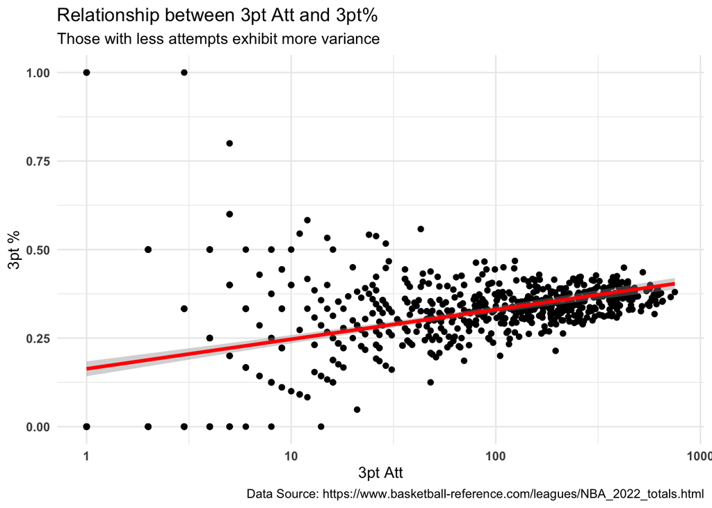

```r
tbl2022 %>%
  ggplot(aes(x = three_pt_att, y = three_pt_pct)) +
  geom_point() +
  geom_smooth(method = "lm",
              color = "red",
              size = 1.2) +
  scale_x_log10() +
  labs(x = "3pt Att",
       y = "3pt %",
       title = "Relationship between 3pt Att and 3pt%",
       subtitle = "Those with less attempts exhibit more variance",
       caption = "Data Source: https://www.basketball-reference.com/leagues/NBA_2022_totals.html")
```

## Bayesian Shrinkage using Beta-Binomial Conjugate

- alpha and beta parameters were previously established as 61.8 and 106.2, respectively, using data from the prior 2 seasons and players with 200 or more 3pt attempts. This provides a prior mean for 3pt% of 36.8%
- The estimation of the alpha and beta parameters can be found [here](https://github.com/pw2/bases_adjusted_3pt_pct)

Update each player using these parameters

```r
alpha <- 61.8
beta <- 106.2

prior_mu <- alpha / (alpha + beta)
prior_mu
```

```
## [1] 0.3678571
```

```r
tbl2022 <- tbl2022 %>%
  mutate(three_pt_missed = three_pt_att - three_pt_made,
         posterior_alpha = three_pt_made + alpha,
         posterior_beta = three_pt_missed + beta,
         posterior_three_pt_pct = posterior_alpha / (posterior_alpha + posterior_beta),
         posterior_three_pt_sd = sqrt((posterior_alpha * posterior_beta) / ((posterior_alpha + posterior_beta)^2 * (posterior_alpha + posterior_beta + 1))))
```

Plot the posterior values on the same log scale

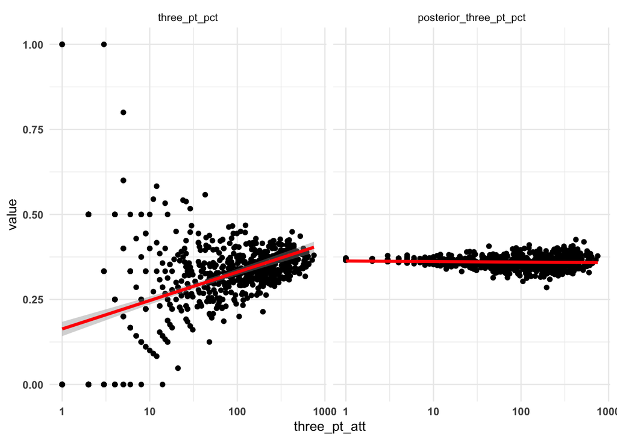

```r
tbl2022 %>%
  dplyr::select(three_pt_att, three_pt_pct, posterior_three_pt_pct) %>%
  pivot_longer(cols = three_pt_pct:posterior_three_pt_pct) %>%
  mutate(name = factor(name, levels = c("three_pt_pct", "posterior_three_pt_pct"))) %>%
  ggplot(aes(x = three_pt_att, y = value)) +
  geom_jitter() +
  geom_smooth(method = "lm",
              color = "red",
              size = 1.2) +
  scale_x_log10() +
  facet_wrap(~name)
```

- We’ve effectively constrained all of the players (shrinkage) towards the prior mean
- Our problem is that the prior mean, 0.368, is too high for the players with a small number of 3pt shots. For example, the players with under 50 attempts have a 3pt % of 30% (median of 25%)

```r
tbl2022 %>%
  filter(three_pt_att < 50) %>%
  summarize(att = sum(three_pt_att),
            three_pt = sum(three_pt_made),
            three_pt_pct_avg = three_pt / att,
            three_pt_pct_median = median(three_pt_pct))
```

```
## # A tibble: 1 × 4
##     att three_pt three_pt_pct_avg three_pt_pct_median
##   <dbl>    <dbl>            <dbl>               <dbl>
## 1  5007     1504            0.300               0.252
```

- While the beta-binomial conjugate is using prior information to help us control for smaller observations and pool/shrink players to the average, those with a lower number of shot attempts are getting overestimated using this approach (IE, we might believe they are better than they really are!).
- We need to account for shot attempts so that we can estimate players with smaller samples to a more proper prior (a prior lower than that being assumed by the alpha and beta parameters from the players with 200 or more three point attempts).

## Accounting for 3pt Shot Attempts

- Our outcome variable is binomial (success and failures) so we will use a beta-binomial regression to estimate a prior for 3pt% while controlling for 3pt shot attempts.

```r
suppressPackageStartupMessages({
  suppressWarnings({
    library(gamlss)
  })
})

fit_3pt <- gamlss(cbind(three_pt_made, three_pt_missed) ~ log(three_pt_att),
                  data = tbl2022,
                  family = BB(mu.link = "identity"))
```

```
## GAMLSS-RS iteration 1: Global Deviance = 4772.898
## GAMLSS-RS iteration 2: Global Deviance = 3960.674
## GAMLSS-RS iteration 3: Global Deviance = 3947.243
## GAMLSS-RS iteration 4: Global Deviance = 3947.242
```

```r
fit_3pt
```

```
##
## Family:  c("BB", "Beta Binomial")
## Fitting method: RS()
##
## Call:  gamlss(formula = cbind(three_pt_made, three_pt_missed) ~
##     log(three_pt_att), family = BB(mu.link = "identity"),      data = tbl2022)
##
##
## Mu Coefficients:
##       (Intercept)  log(three_pt_att)
##           0.21661            0.02489
## Sigma Coefficients:
## (Intercept)
##      -6.128
##
##  Degrees of Freedom for the fit: 3 Residual Deg. of Freedom   737
## Global Deviance:     3947.24
##             AIC:     3953.24
##             SBC:     3967.06
```

```r
## extract model coefficients
fit_3pt$mu.coefficients
```

```
##       (Intercept) log(three_pt_att)
##        0.21660570        0.02489146
```

```r
fit_3pt$sigma.coefficients
```

```
## (Intercept)
##   -6.127507
```

```r
mu_intercept <- as.vector(fit_3pt$mu.coefficients[1])
mu_shot <- as.vector(fit_3pt$mu.coefficients[2])
sigma_shot <- as.vector(exp(fit_3pt$sigma.coefficients))
```

**Fitting an estimate to each player using our new prior that is accounting for 3 point shot attempts**

- Instead of the single alpha and beta parameters we used before we will chose a prior for each player based on their number of 3 point shot attempts and then update their performance.
- To use the equation for calculating a player’s estimated 3pt%:

$mu = mu.intercept + mu.shot*log(three.pt.att)$

- Using the `predict()` function, we can have our model make this `mu` prediction for every player, representing their initial prior based on their 3 point shot attempts.

**NOTE:** sigma will be the same for all players, representing the variance that we expect all of those in the population to similarly to exhibit.

```r
tbl2022 <- tbl2022 %>%
  mutate(mu = fitted(fit_3pt, parameter = "mu"),
         sigma = fitted(fit_3pt, parameter = "sigma"),
         prior_alpha_reg = mu / sigma,
         prior_beta_reg = (1 - mu) / sigma,
         posterior_alpha_reg = prior_alpha_reg + three_pt_made,
         posterior_beta_reg = prior_beta_reg + three_pt_missed,
         posterior_mu_reg = posterior_alpha_reg / (posterior_alpha_reg + posterior_beta_reg))
```

**Plot the changes between our beta-binomial conjugate posterior and our beta-binomial regression posterior**

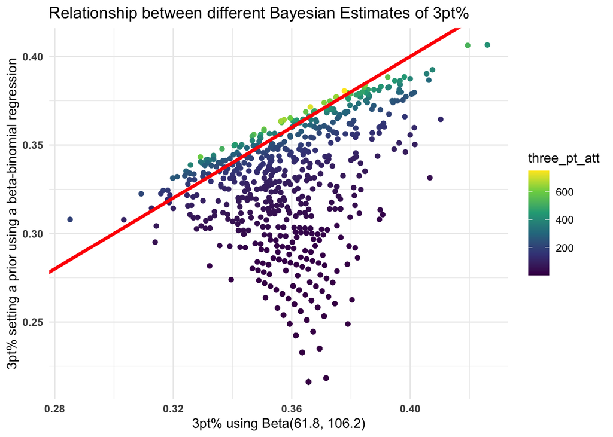

```r
tbl2022 %>%
  ggplot(aes(x = posterior_three_pt_pct, y = posterior_mu_reg, color = three_pt_att)) +
  geom_point() +
  geom_abline(color = "red",
              size = 1.3,
              intercept = 0,
              slope = 1) +
  scale_color_continuous(type = 'viridis') +
  labs(title = "Relationship between different Bayesian Estimates of 3pt%",
       x = "3pt% using Beta(61.8, 106.2)",
       y = "3pt% setting a prior using a beta-binomial regression")
```

- Notice that those with more 3 point attempts are close to the red line, representing perfect agreement between the two estimates(intercept = 0, slope = 1) while those with less attempts are pulled further down, indicating poorer estimated 3pt performance.

**Plot the raw, beta-binomial conjugate, and beta-binomial regression outputs**

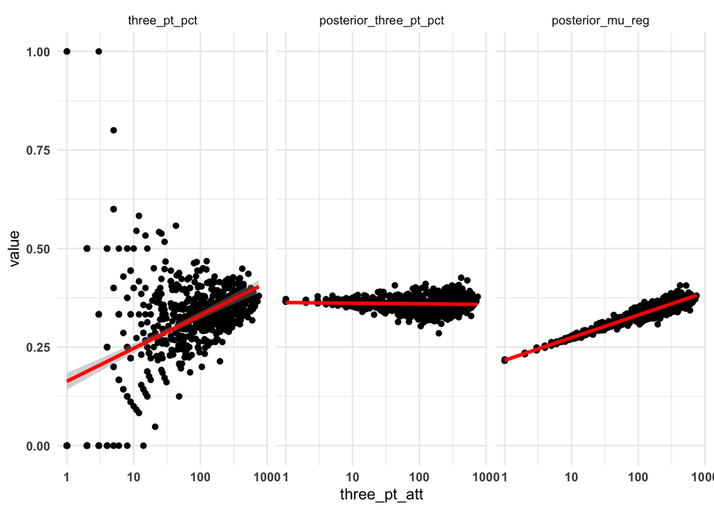

```r
tbl2022 %>%
  dplyr::select(three_pt_att, three_pt_pct, posterior_three_pt_pct, posterior_mu_reg) %>%
  pivot_longer(cols = three_pt_pct:posterior_mu_reg) %>%
  mutate(name = factor(name, levels = c("three_pt_pct", "posterior_three_pt_pct", "posterior_mu_reg"))) %>%
  ggplot(aes(x = three_pt_att, y = value)) +
  geom_jitter() +
  geom_smooth(method = "lm",
              color = "red",
              size = 1.2) +
  scale_x_log10() +
  facet_wrap(~name)
```

- In the right most plot (beta-binomial regression prior) we see those with a small number of 3pt attempts are shrunk to a smaller prior three point percentage than those with a larger number of 3pt attempts.

## Make an estimation for a new player who has 10 three point attempts

```r
new_player <- data.frame(
  three_pt_att = 10,
  three_pt_made = 2,
  three_pt_missed = 10 - 2,
  three_pt_pct = 2 / 10
)

new_player %>%
  mutate(mu = predict(fit_3pt, newdata = new_player),
         sigma = exp(fit_3pt$sigma.coefficients),
         prior_alpha = mu / sigma,
         prior_beta = (1 - mu) / sigma,
         posterior_alpha = prior_alpha + three_pt_made,
         posterior_beta = prior_beta + three_pt_missed,
         posterior_mu = posterior_alpha / (posterior_alpha + posterior_beta)) %>%
  pivot_longer(cols = everything())
```

```
## # A tibble: 11 × 2
##    name                value
##    <chr>               <dbl>
##  1 three_pt_att     10
##  2 three_pt_made     2
##  3 three_pt_missed   8
##  4 three_pt_pct      0.2
##  5 mu                0.274
##  6 sigma             0.00218
##  7 prior_alpha     126.
##  8 prior_beta      333.
##  9 posterior_alpha 128.
## 10 posterior_beta  341.
## 11 posterior_mu      0.272
```

## Useful Resources

Some textbooks that I’ve found useful for exploring this type of work:

- Introduction to Empirical Bayes: Examples from Baseball Statistics by David Robinson (this blog post was inspired by David’s approach to batting statistics in Chapter 7)
- [Bayesian Computation with R by Jim Albert](https://www.amazon.com/Bayesian-Computation-R-Use/dp/0387922970/ref=sr_1_1?keywords=bayesian+computation+with+r&qid=1650842246&sprefix=bayesian+comput%2Caps%2C150&sr=8-1)
- [Bayesian Data Analysis by Gelman et al](https://www.amazon.com/Bayesian-Analysis-Chapman-Statistical-Science/dp/1439840954/ref=sr_1_1?crid=519JX5YHJBU5&keywords=Bayesian+Data+Analysis&qid=1650842283&sprefix=bayesian+data+analysis%2Caps%2C151&sr=8-1)